# Exponential Distribution and Central Limit Theorem Simulation Exercise

December 31, 2016

## 1. Justification and Background

The shiny application developed explains the Effect of Lambda, No. of Observations and No. of Exponentials in Exponential Distribution and Central Limit Theorem Simulation

There are 3 slider controls to change either of the parameters. Based on the changes in slider controls, the graphs are updated automatically. Refreshing the graphs lags a bit due to the random number generation.

The reason to develop this particular app using shiny because of the following reasons

- The power of interacive charts and apps resides in the capacity to engage users to act upon controls and see immediate responses in parameters inputs and changes.
- Analytics, data science and statitical analysis benefit significantly from the new power unleashed by open source code and the internet.

```r
# 5.1 Generating and plotting Exponential Distribution
print (paste ("Actual and Theoretical means are", round(mean(vectMeans),2), round (1/lambda, 2)))
```

```
## [1] "Actual and Theoretical means are 5 5"
```

```r
# 5.2 Sample Variance versus Theoretical Variance
print (paste ("Actual and Theoretical Variances are", var(vectMeans), "((1/",lambda,")^2)/",noExp,"=",(((1/lambda)^2)/noExp)))
```

```
## [1] "Actual and Theoretical Variances are 0.646565095346858 ((1/ 0.2 )^2)/ 40 = 0.625"
```

## 2. Exponential Distribution - Scatter Plot and histogram

The scatter plot containing exponential distribution with certain lambda and number of observations plots the random numbers generated while performing the experiments. Similarly, the histogram "Exponential Distribution's mean distribution" graph displays the distribution of the mean of the random numbers generated.

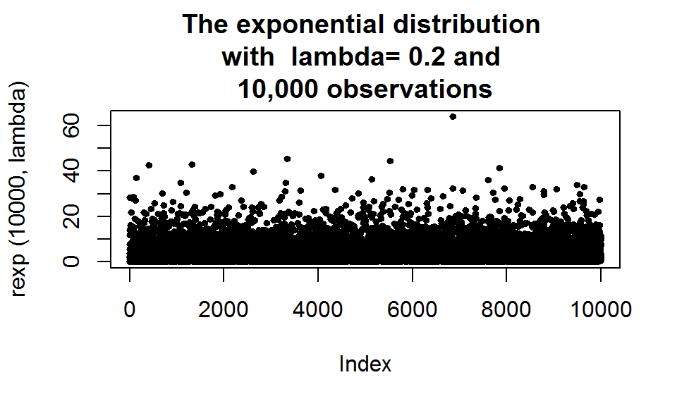

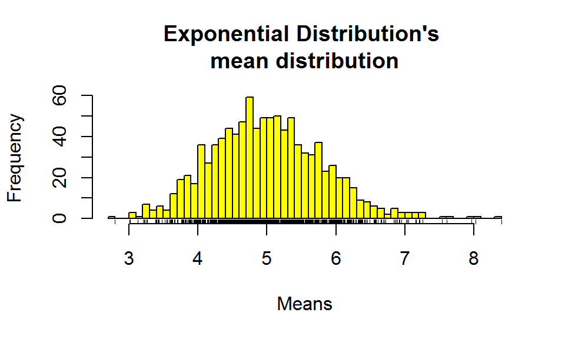

## 3. Normal vs. Exponential Distribution

Histogram "for "Theoretical vs. Actual mean for Exponential Distribution"" displays the difference between both the values which is very minimal confined to second digit after decimal point. Histogram "Exponential and Normal Distribution" displays the calculated distribution of means of random sampled Exponantial Distributions overlaps with the Normal Distribution, due to the Central Limit Theorem. The more samples we would get, the closer will the density distribution be to the normal distribution bell curve.

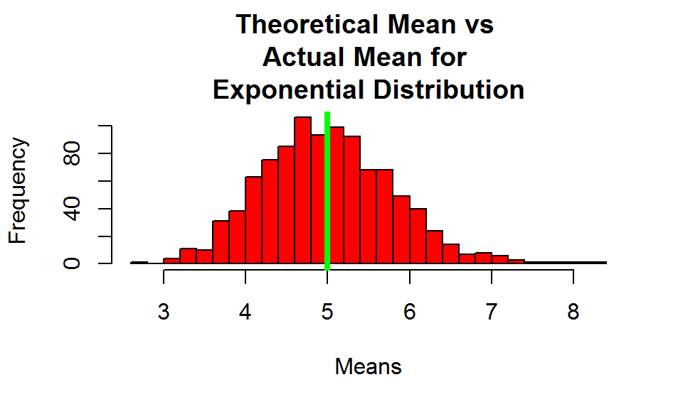

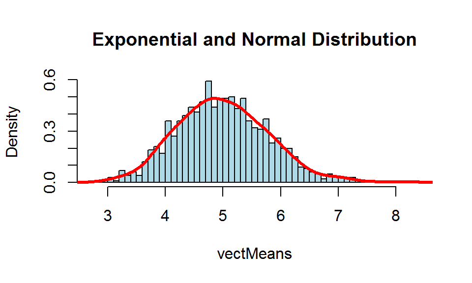

## Code & other details

shinyUI(fluidPage(sidebarLayout( sidebarPanel( sliderInput("lambda", "Lambda or Theorotical Mean:", min = 0.1, max = 1, value = 0.2, step = 0.1), sliderInput("noSim", "No. of Observations / Simulations:", min = 1000, max = 100000, value = 1000, step = 1000), sliderInput("noExp", "No. of Exponentials:", min = 10, max = 100, value = 40, step = 10), h5("Use the slider controls on the left pane to adjust / select:"), h5(" 1. Lambda / Theorotical Mean"), h5(" 2. No. of Observations / Simulations"), h5(" 3. No. of Exponentials"), h5("The charts will be adjusted automatically to reflect the impact of selected inputs on the distribution")), mainPanel(fluidRow(column (5, plotOutput("scatterPlot")),column (5, plotOutput("histPlot1"))), fluidRow(column (5, plotOutput("histPlot2")),column (5, plotOutput("histPlot3")))))

Shiny application is deployed at https://nbrahman.shinyapps.io/week4_assignment/

The Shiny app source code is available at https://github.com/nbrahman/Coursera/tree/master/Data%20Science/9.%20Developing%20Data%20Products/Week%204%20-%20Shiny%20Application%20and%20Reproducible%20Pitch/week4_assignment

The presentation source code is available at https://github.com/nbrahman/Coursera/tree/master/Data%20Science/9.%20Developing%20Data%20Products/Week%204%20-%20Shiny%20Application%20and%20Reproducible%20Pitch